# Section 5 - Assessment

@uthor: Steven Ponce

Date: 2022-01-18

## Libraries, Options, and Data

```r
# library(dplyr)
# library(ggplot2)
# library(dslabs)
# library(RColorBrewer)
# library(tidyquant)
# data(us_contagious_diseases)

# report 3 significant digits
options(digits = 3)
```

## Exercise 1: Tile plot - measles and smallpox

Instructions:

- Modify the tile plot to show the rate of smallpox cases instead of measles cases.
- Exclude years in which cases were reported in fewer than 10 weeks from the plot.

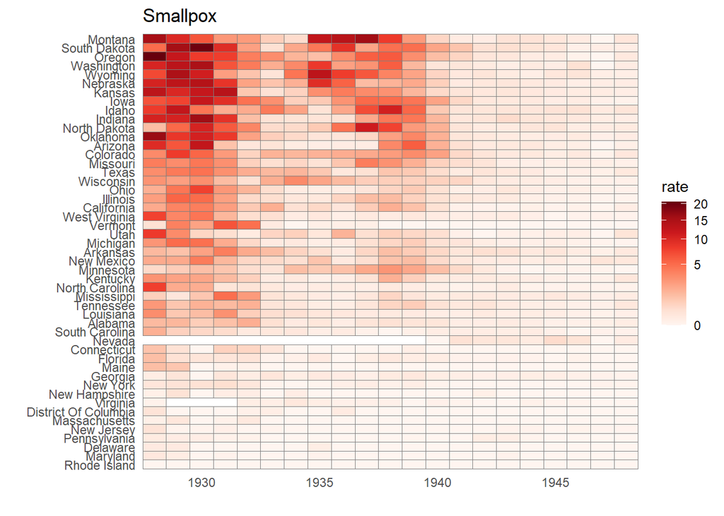

```r
the_disease = "Smallpox"
dat <- us_contagious_diseases %>%
  filter(!state%in%c("Hawaii","Alaska") & disease == the_disease) %>%
  filter(weeks_reporting >= 10) %>%
  mutate(rate = count / population * 10000) %>%
  mutate(state = reorder(state, rate))

dat %>% ggplot(aes(year, state, fill = rate)) +
  geom_tile(color = "grey50") +
  scale_x_continuous(expand=c(0,0)) +
  scale_fill_gradientn(colors = brewer.pal(9, "Reds"), trans = "sqrt") +
  theme_minimal() +
  theme(panel.grid = element_blank()) +
  ggtitle(the_disease) +
  ylab("") +
  xlab("")
```

## Exercise 2. Time series plot - measles and smallpox

Instructions:

- Modify the sample code for the time series plot to plot data for smallpox instead of for measles.
- Once again, restrict the plot to years in which cases were reported in at least 10 weeks.

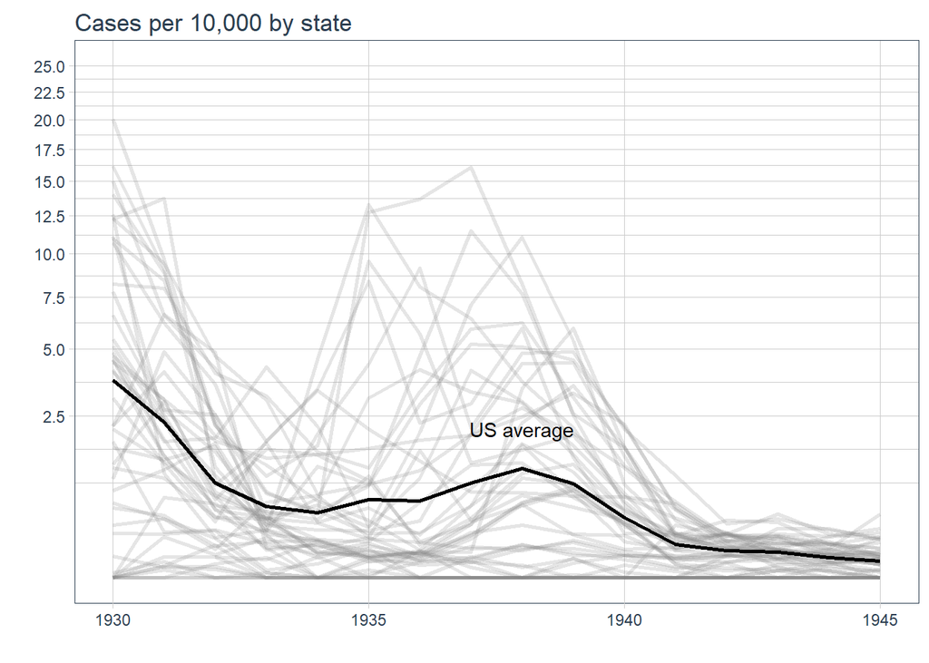

```r
# compute US average measles rate by year
the_disease = "Smallpox"
dat <- us_contagious_diseases %>%
  filter(!state%in%c("Hawaii","Alaska") & disease == the_disease) %>%
  filter(weeks_reporting >= 10) %>%
  mutate(rate = count / population * 10000) %>%
  mutate(state = reorder(state, rate))

avg <- us_contagious_diseases %>%
  filter(disease==the_disease) %>% group_by(year) %>%
  summarize(us_rate = sum(count, na.rm=TRUE)/sum(population, na.rm=TRUE)*10000)

# make line plot of measles rate by year by state
dat %>%
  filter(!is.na(rate)) %>%
  ggplot() +
  geom_line(aes(year, rate, group = state), color = "grey50",
            show.legend = FALSE, alpha = 0.2, size = 1) +
  geom_line(mapping = aes(year, us_rate), data = avg, size = 1, col = "black") +

  scale_x_continuous(breaks = seq(1930, 1945, by = 5), limits = c(1930, 1945)) +

  scale_y_continuous(trans = "sqrt", breaks = seq(0, 25, by = 2.5), limits = c(0, 25)) +

  ggtitle("Cases per 10,000 by state") +
  xlab("") +
  ylab("") +
  geom_text(data = data.frame(x = 1938, y = 2.1),
            mapping = aes(x, y, label = "US average"), color = "black") +
  theme_tq()
```

## Exercise 3: Time series plot - all diseases in California

Instructions:

- For the state of California, make a time series plot showing rates for all diseases.
- Include only years with 10 or more weeks reporting.
- Use a different color for each disease. Include your aes function inside of ggplot rather than inside your geom layer.

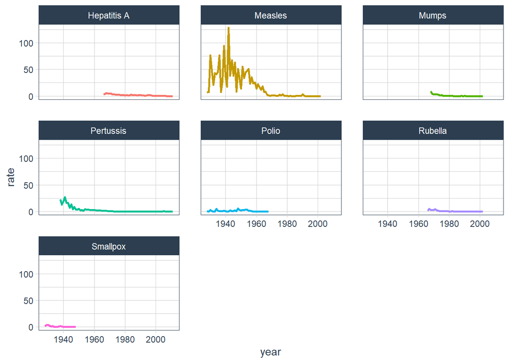

```r
us_contagious_diseases %>% filter(state=="California") %>%
  filter(weeks_reporting >= 10) %>%
  group_by(year, disease) %>%
  summarize(rate = sum(count)/sum(population)*10000) %>%
  ggplot(aes(year, rate, color = disease)) +
  geom_line(size= .9) +
  facet_wrap(disease ~ .) +
  theme_tq()+
  theme(legend.position = "none")
```

## Exercise 4: Time series plot - all diseases in the United States

Instructions:

- Compute the US rate by using summarize to sum over states. Call the variable rate.
- The US rate for each disease will be the total number of cases divided by the total population.
- Remember to convert to cases per 10,000. You will need to filter for `!is.na(population)` to get all the data.
- Plot each disease in a different color.

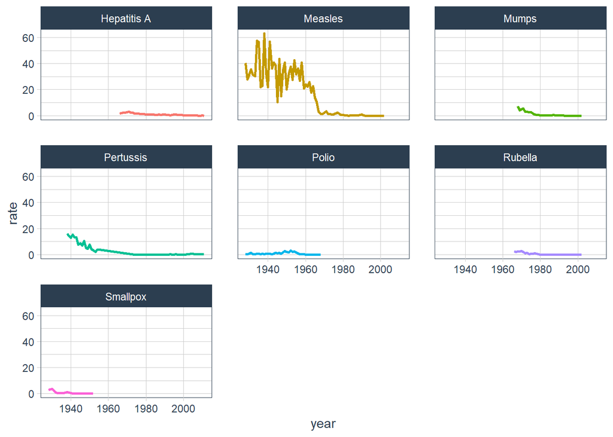

```r
us_contagious_diseases %>%
  filter(!is.na(population)) %>%

  group_by(year, disease) %>%
  summarize(rate = sum(count)/sum(population)*10000) %>%
  ggplot(aes(year, rate, color = disease)) +
  geom_line(size= .9) +
  facet_wrap(disease ~ .) +
  theme_tq()+
  theme(legend.position = "none")
```